# BSAN2204

Lecture 5

R Skills Quiz (A1)

Lecture Briefing

## R Skills Tutorial Quiz (A1)

The R Skills Tutorial Quiz (A1) occurs during tutorials as a paper based assessment testing basic knowledge about R as a tool for business analytics taught in the first part of the of the course.

This assessment requires students to internalise the basics of R necessary to independently start an R project, critique R syntax and/or troubleshoot basic R errors without a reliance on AI tools. The feedback students receive on this early piece of assessment is intended to sign post which of their R skill development areas they need to address before being able to confidently and independently get started on the Predictive Analytics (A2) and for completing the final Practical Demonstration (A3).

## Quiz Information

The quiz will consist of 30 multiple‑choice questions assessing your understanding of core `R` concepts, including basic functions, syntax, RStudio, and RMarkdown. Some questions will be conceptual (about `R`) whilst others will be practical code questions (e.g., choosing the correct syntax).

The quiz is paper‑based. You may not bring notes, devices, or any electronic aids.

You must sit the quiz in your allocated tutorial unless you have received permission from the Course Coordinator to attend a different session.

## What will happen on the day

During your tutorial, your tutor will hand out a printed booklet that contains the 30 multiple questions. Answers are the be indicated on a separate answer sheet by shading in boxes.

You will write your name and student ID number on both the question booklet and answer sheet, and hand in both once you have completed the quiz.

Your tutor will move through the classroom during the assessment time to check individual student IDs against the roll of student signed on to that session.

**Bring your student ID card!**

## Identity Verified Assessment

**Students must bring their student ID card**.

[figure not shown]

Do not confuse your `character` student **username** (e.g., “s4123456”) with your `numeric` **8 digit** student ID (e.g., 41234567).

```r
class("s4123456")
```

```
[1] "character"
```

```r
class(41234567)
```

```
[1] "numeric"
```

## R Skills Tutorial Quiz (A1) - Answer Sheet

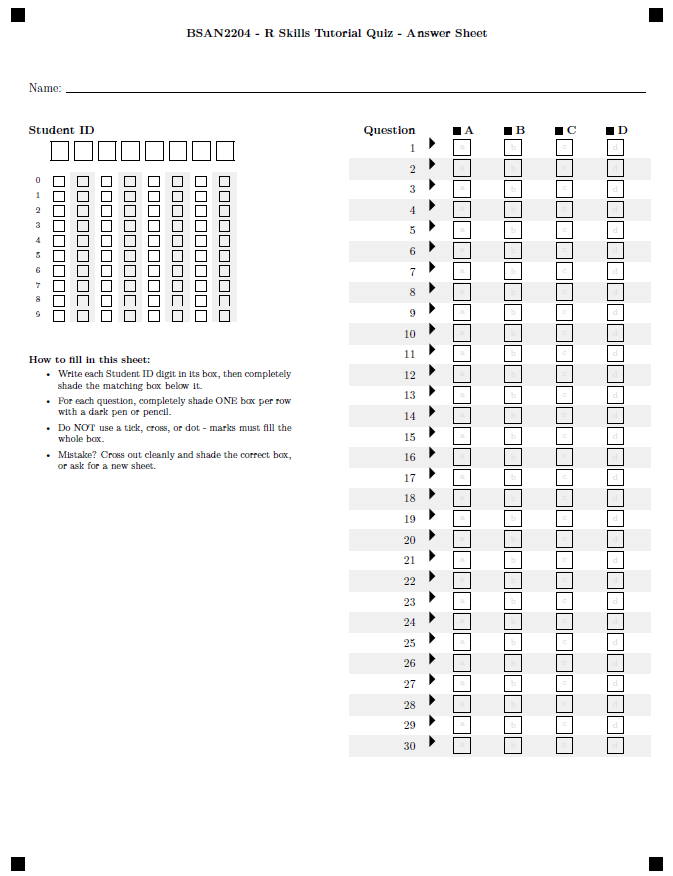

- Use a dark pen or dark pencil.
- SHADE IN EACH BOX. Do NOT use a tick, cross, or dot (see example).
- Write each Student ID digit in its box, then completely shade the matching box below it (see example).
- Keep your mark fully inside the box. Do not let pen strokes extend above, below, or beside it. This may result in incorrect marking.
- Mark exactly one box per row. Marking more than one box for the same question will be treated as no answer.
- It is recommended to mark your answers within your question booklet and then transfer these to your answer sheet to avoid having to correct mistakes. If you make a mistake: erase/whiteout the unintended marks completely. If marks cannot be completely removed, put your hand up and ask for a new answer sheet.
- Do NOT write your answers as letters (A/B/C/D) next to the row — only the shaded box will be marked.

## OMR (Optical Mark Recognition) Form

Your responses on the R Skills Tutorial Quiz (A1) answer sheet will be read using OMR, this includes both your `numeric` (not `character`) **8 digit student ID** and your multi-choice answers. It is important that you take care to fill in these boxes appropriately to ensure your responses are accurately recorded.

**Example**:

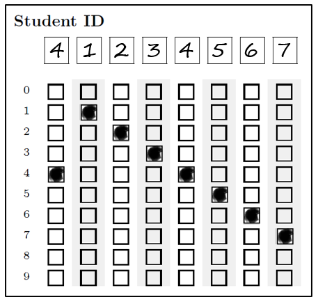

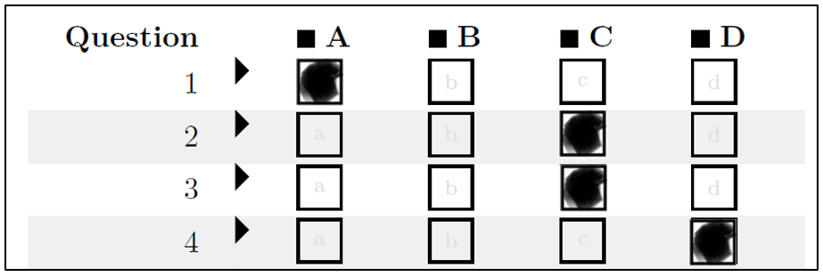

## Permitted (and recommended) materials

Writing utensils only: pencil, eraser, pen, whiteout correction fluid/tape

It is **recommended** to bring a dark 2B pencil and an eraser:

[figure not shown]

[figure not shown]

## Suggested study areas

- Using square brackets `[ , ]` with row and column references.
- Variable naming rules in `R`
- `attach()`, `library()`, `install.packages()`, `kable()`, etc.
- Local vs Global environment
- R Markdown
- Basic data types in `R` (e.g., `character` vs `numeric`)
- Pipe `|>` operator
- Console outputs (how to report them)
- Common error messages

…among others

## Example Questions on R Skills Quiz (A1)

Which of the following is accurately describes the difference in purpose of the R script editor window vs the R console window within R studio.

a) The R script editor is where R scripts are executed, whilst the console window is where R scripts are written and edited.

b) The R script editor is an interactive environment for modifying R packages, whilst the R console is where R packages are stored.

c) The R script editor is used to adjust R studio settings, whilst the R console is where R plots/graphics are displayed.

d) The R script editor is where R scripts are written and edited, whilst the console is where R scripts are executed and text outputs are displayed.

Which of these is correct?

## Example Questions on R Skills Quiz (A1)

Which line of R code which creates object called “my_vector” that contains a numeric vector of numbers from 1 to 10?

a) `my_vector <- c(1:10)`

b) `my vector <- c(1:10)`

c) `my_vector <- 1,2,3,4,5,6,7,8,9,10`

d) `my_vector <- combine(1 to 10)`

Which of these is correct?

a) is correct

b) is wrong, as variable names cannot contain spaces,

c) is wrong, as `1,2,3...` is not valid syntax,

d) is wrong, as `combine(1 to 10)` is not valid syntax.

## Suggested revision strategy

You should revise the lecture and tutorial content, applying it by running the example code shown in lectures in `R` and building out the template `.Rmd` file for the `MSD` project from the tutorial notes.

Many of the core skills necessary to get started on the `Predictive Analytics Report (A2)` are tested in this quiz, as such by attempting to make a start on that report and troubleshooting any errors along the way by reading the course notes or `R` documentation.

Given `R` is a statistical programming language, developing strong `R` skills requires practical application (not just passive reading/listening!), as is the case with all languages (both human and computer!)

## Preparing for the R Skills Quiz (A1)

The quiz assesses core skills and concepts covered in tutorials and lectures. Revise the slides as many correct answers (both text and code) appear verbatim there.

Doing well requires a solid grasp of the basics from the first part of the course, and these same skills are the foundation you will need to start the **Predictive Analytics Report (A2)**.

Tip: Focus on syntax, key functions, RStudio workflow, and R Markdown conventions that are emphasised in the slides.

Thank you!